# MEDL_HW03_Soln

**Deep Learning for Mechanical Engineering**  
**Homework 03 - Solution**  
**Due Tuesday, 04/14/2020, 3:30 PM**

By Prof. Seungchul Lee  
http://iai.postech.ac.kr/  
Industrial AI Lab at POSTECH

- For your handwritten solution, scan or take a picture of them.
- For your code, only .ipynb file will be graded.
  - Please write your NAME and student ID on your .ipynb files. ex) KangsanLee_20202467_HW03.ipynb
- Please compress all the files to make a single .zip file
  - Please write your NAME and student ID on your .zip files. ex) NamjeongLee_20202407_HW03.zip
  - Submit it to LSM
- Do not submit a printed version of your code. It will not be graded.

## Problem 1: [Hand written] Shortest Distance Between Point and Hyperplane.

Let $f(x_1,x_2) = 2x_1 + 3x_2 + 1 = 0$ be the hyperplane (or decision surface in classification problems). Compute the shortest distances from $x_a = \begin{bmatrix} 2 \\1\end{bmatrix}$ and $x_b = \begin{bmatrix} 1 \\ -1\end{bmatrix}$ to the above hyperplane.

**Solution**

Distance from the line to arbitrary vector x

$$h = \frac{g(x)}{\lVert \omega \rVert}$$

$$\begin{align*} f(x_1, x_2) &= 2x_1 + 3x_2 + 1 = 0\\ f(\vec x) &= \begin{bmatrix}2& 3\end{bmatrix} \begin{bmatrix}x_1\\ x_2\end{bmatrix} + 1 = \omega^Tx + 1 = 0 \\ \end{align*}$$

$$\begin{align*} h_a &= \frac{g(x_a)}{\lVert \omega \rVert} = \frac{(4+3+1)}{\sqrt{13}}= \frac{8}{\sqrt{13}}\\ h_b &= \frac{g(x_b)}{\lVert \omega \rVert} = \frac{2-3+1}{\sqrt{13}} = 0 \end{align*}$$

## Problem 2: [Hand written] Orthogonality

Let $g(x) = \omega^T x + b = 0$ be a hyperplane for some data set. Prove that the line $g(x)=0$ and $\omega$ are orthogonal.

Note: The inner product become zero when two vectors are orthogonal.

**Solution**

Let $p_1$ and $p_2$ are on the line $g(x)=0$.

Then, we can rewrite the equation as follows:

$$\omega^T p_1 + b = 0 \dots (a)\\ \omega^T p_2 + b = 0 \dots (b)$$

$$\omega^T (p_1-p_2)= 0$$

Thus, $\omega^T$ and $(p_1-p_2)$ are orthogonal. And since $(p_1-p_2)$ also on the line $g(x)=0$, $g(x)=0$ and $\omega^T$ are orthogonal.

## Problem 3: Multi-class Classification with Logistic Regression

You will classify some hand-written digits(MNIST dataset) using Logistic Regression. You have learned about the probability function for binary classification. What you are going to do is multi-class classification. You must use Tensorflow for training.

(1) [Hand written] For binary classification, we've used the distance between points and decision boundary as a probability. Then, let's calculate the probability, maxmum likelihood, and gradient of maximum likelihood for K-class case.

Note: You should calculate the odds ratio of K classes first. In logistic regression, the odds ratio represents the constant effect of a predictor X, on the likelihood that one outcome will occur. In other words, we need to measure the unique effect of each X on Y.

### Solution

Since the principle underlying logistic regression doesn't change but the increasing classes, we need to calculate odd ratio for each of the K classes.

Since now we have K number of class, we need to consider the calculated probability p of class i.

$$\text{Class} \space 1: \ln\frac{p_1}{p_K} = \omega_1^T X \\ \text{Class} \space 2: \ln\frac{p_2}{p_K} = \omega_2^T X \\ \vdots\\ \text{Class} \space K: p_K = 1- \sum_{i=1}^{K-1}p_i$$

Then, we can calculate each p_i.

$$p_1 = p_K e^{\omega_1^T X}\\ p_2 = p_K e^{\omega_2^T X}\\ \vdots \\ p_K = 1-p_K \sum_{i=1}^{K-1}e^{\omega_i^T X}$$

Thus,

$$p_K = \frac{1}{1+ \sum_{i=1}^{K-1}e^{\omega_i^T X}}$$

and

$$p_1 = \frac{e^{\omega_1^T X}}{1+ \sum_{i=1}^{K-1}e^{\omega_i^T X}}\\ p_2 = \frac{e^{\omega_2^T X}}{1+ \sum_{i=1}^{K-1}e^{\omega_i^T X}}\\ \vdots \\ p_{K-1} = \frac{e^{\omega_{K-1}^T X}}{1+ \sum_{i=1}^{K-1}e^{\omega_i^T X}}$$

And the maximum log likelihood function becomes:

$$L(\omega_i^T, X) = \sum_{i=1}^{N} \log(p_i(x_i,\omega_i^T)) = \sum_{i=1}^{N} \log\frac{e^{\omega_{i}^T X}}{1+ e^{\omega_i^T X}}$$

And the gradient becomes:

$$ \begin{align}\frac{\partial}{\partial \beta} L(\beta,x_i)& = \sum_{i=1}^N \frac{\partial}{\partial \beta}y_i \beta^T x_i -\frac{\partial}{\partial \beta} \log(1+e^{\beta^T x_i})\\ & =\sum_{i=1}^N y_i x_i - \frac{x_i e^{\beta^T x_i}}{1+e^{\beta^T x_i}}\\ & =\sum_{i=1}^N x_i(y_i-p_i) \end{align} $$

**Load data**

The MNIST database (Modified National Institute of Standards and Technology database) is a large database of handwritten digits that is commonly used for training various image processing systems.

Tensorflow provides a collection of ready-to-use datasets.

```python
import warnings
warnings.simplefilter(action='ignore', category=FutureWarning)

import matplotlib.pyplot as plt
import numpy as np

import tensorflow as tf
from tensorflow.examples.tutorials.mnist import input_data

mnist = input_data.read_data_sets("MNIST_data/", one_hot=False, reshape=True)

print(mnist.train.images.shape, mnist.train.labels.shape)
print(mnist.test.images.shape, mnist.test.labels.shape)
```

[output not shown]

(2) Using the digits 1, 4, 8 only, plot a random image for each class in trainset.  
hint: each image has shape of 28 x 28.

```python
# Your code here
```

```
(6179, 784) (5307, 784) (5389, 784)
(6179,) (5307,) (5389,)
```

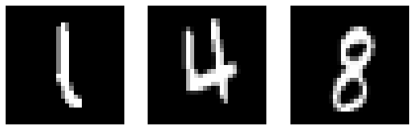

```python
# Solution
x_train_one = mnist.train.images[np.where(mnist.train.labels == 1)]
x_train_four = mnist.train.images[np.where(mnist.train.labels == 4)]
x_train_eight = mnist.train.images[np.where(mnist.train.labels == 8)]

y_train_one = mnist.train.labels[np.where(mnist.train.labels == 1)]
y_train_four = mnist.train.labels[np.where(mnist.train.labels == 4)]
y_train_eight = mnist.train.labels[np.where(mnist.train.labels == 8)]

print(x_train_one.shape, x_train_four.shape, x_train_eight.shape)
print(y_train_one.shape, y_train_four.shape, y_train_eight.shape)

plt.figure(figsize=(9, 3))
plt.subplot(131)
plt.imshow(x_train_one[np.random.randint(len(x_train_one))].reshape(28, 28), plt.cm.gray); plt.axis('off')
plt.subplot(132)
plt.imshow(x_train_four[np.random.randint(len(x_train_four))].reshape(28, 28), plt.cm.gray); plt.axis('off')
plt.subplot(133)
plt.imshow(x_train_eight[np.random.randint(len(x_train_eight))].reshape(28, 28), plt.cm.gray); plt.axis('off')
plt.show()
```

(3) Reshape the dataset. Transform the label data into the one-hot encoding and stack all the data.  
hint: `tf.keras.utils.to_categorical()` and `np.vstack()`

```python
# Your code here
```

```python
# Solution
num_classes = 10

y_train_one = tf.keras.utils.to_categorical(y_train_one, num_classes)
y_train_four = tf.keras.utils.to_categorical(y_train_four, num_classes)
y_train_eight = tf.keras.utils.to_categorical(y_train_eight, num_classes)
y_test = tf.keras.utils.to_categorical(mnist.test.labels, num_classes)

x_train = np.vstack([x_train_one, x_train_four, x_train_eight])
y_train = np.vstack([y_train_one, y_train_four, y_train_eight])

print(x_train.shape, y_train.shape)
```

```
(16875, 784) (16875, 10)
```

(4) Implement your logistic regression model and train it. The accuracy for the test set should be higher than 80%

Note: Use all the pixel values as a feature vector. (784 # of features)

```python
# Your code here
```

```python
# Solution

num_features = 784
num_labels = 10
learning_rate = 0.05
batch_size = 128
num_steps = 5001

x_test = np.vstack([mnist.test.images[np.where(mnist.test.labels == i)] for i in (1, 4, 8)])
y_test = np.vstack([y_test[np.where(mnist.test.labels == i)] for i in (1, 4, 8)])

X = tf.placeholder(tf.float32, shape=(None, num_features))
Y = tf.placeholder(tf.float32, shape=(None, num_labels))

W = tf.Variable(tf.truncated_normal([num_features, num_labels]))
b = tf.Variable(tf.zeros([num_labels]))

logits = tf.matmul(X, W) + b
loss = tf.reduce_mean(tf.nn.softmax_cross_entropy_with_logits(labels=Y, logits=logits))

optimizer = tf.train.GradientDescentOptimizer(learning_rate).minimize(loss)

pred = tf.nn.softmax(logits)

def accuracy(predictions, labels):
    correctly_predicted = np.sum(np.argmax(predictions, 1) == np.argmax(labels, 1))
    accu = (100.0 * correctly_predicted) / predictions.shape[0]
    return accu

session = tf.Session()

session.run(tf.global_variables_initializer())
print("Initialized")

for step in range(num_steps):
    offset = np.random.randint(0, y_train.shape[0] - batch_size - 1)

    batch_data = x_train[offset:(offset + batch_size), :]
    batch_labels = y_train[offset:(offset + batch_size), :]

    feed_dict = {X : batch_data,
                 Y : batch_labels}

    _, l, predictions = session.run([optimizer, loss, pred],
                                    feed_dict=feed_dict)

    if (step % 500 == 0):
        print("Minibatch loss at step {0}: {1}".format(step, l))
        print("Minibatch accuracy: {:.1f}%".format(
            accuracy(predictions, batch_labels)))

print("\nTest accuracy: {:.1f}%".format(accuracy(session.run(pred, feed_dict={X:x_test}), y_test)))
```

```
WARNING:tensorflow:From <ipython-input-7-334df31ea6c1>:19: softmax_cross_entropy_with_logits (from tensorflow.python.ops.nn_ops) is deprecated and will be removed in a future version.
Instructions for updating:

Future major versions of TensorFlow will allow gradients to flow
into the labels input on backprop by default.

See `tf.nn.softmax_cross_entropy_with_logits_v2`.

Initialized
Minibatch loss at step 0: 10.891218185424805
Minibatch accuracy: 1.6%
Minibatch loss at step 500: 0.1474359929561615
Minibatch accuracy: 94.5%
Minibatch loss at step 1000: 0.3553306460380554
Minibatch accuracy: 93.0%
Minibatch loss at step 1500: 0.11565020680427551
Minibatch accuracy: 96.9%
Minibatch loss at step 2000: 0.08289213478565216
Minibatch accuracy: 96.9%
Minibatch loss at step 2500: 0.1288004219532013
Minibatch accuracy: 98.4%
Minibatch loss at step 3000: 0.10764946788549423
Minibatch accuracy: 97.7%
Minibatch loss at step 3500: 0.1469075083732605
Minibatch accuracy: 96.1%
Minibatch loss at step 4000: 0.08650518953800201
Minibatch accuracy: 98.4%
Minibatch loss at step 4500: 0.06097549945116043
Minibatch accuracy: 99.2%
Minibatch loss at step 5000: 0.13991384208202362
Minibatch accuracy: 97.7%

Test accuracy: 97.8%
```

(5) Plot a random image and predict it using trained model. Compare it with true label.

```python
# Your code here
```

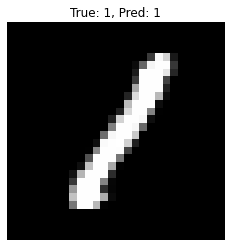

```python
# Solution
r = np.random.randint(len(x_test))
plt.figure(figsize=(4, 4))
plt.title('True: {}, Pred: {}'.format(np.argmax(y_test[r]), np.argmax(session.run(pred, feed_dict={X: x_test[r:r+1]}))))
plt.imshow(x_test[r].reshape(28, 28), cmap=plt.cm.gray)
plt.axis('off')
plt.show()
```